# Peak GHG emissions

Countries that have reached peak GHG emissions

[William F. Lamb](https://lambwf.github.io/) | [Source Code](https://github.com/lambwf/Countries-that-reached-peak-emissions/)

# Which countries have reduced emissions?

Global greenhouse gas (GHG) emissions are still [rising](https://lambwf.github.io/UNEP-Gap-Report-2024-Chapter-2/), but many countries have already peaked and reduced emissions for more than 10 years. These countries are interesting because they could tell us about which types of climate and energy policies are successful, under what conditions and why. They could also tell us where bottlenecks and limits to emissions reductions could be faced. As of 2022, most countries with sustained emissions reductions are in Europe or belong to the OECD. But there are also many high-income countries that have yet to peak in emissions.

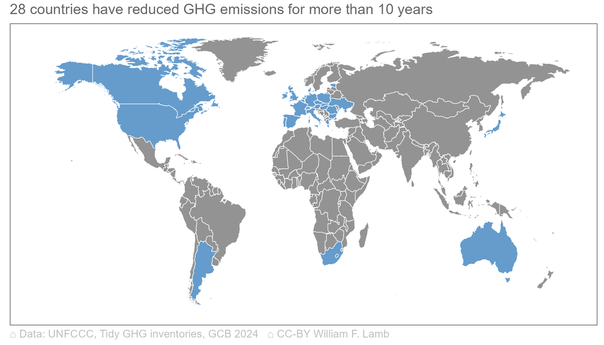

# By which metrics have they reduced emissions?

This analysis is an update of [Lamb et al. 2021](https://www.tandfonline.com/doi/full/10.1080/14693062.2021.1990831), which describes the method in more detail. I look for emissions reductions of at least 10 years in three metrics:

- Total GHG Emissions, based on the [latest national inventory submissions](https://lambwf.github.io/Tidy-GHG-Inventories/) to the UNFCCC
- Total GHG Emissions, excluding the land use, land use change and forestry (LULUCF) sector (net CO₂ removals can change the trend in some countries)
- Consumption based CO₂ emissions, based on the [Global Carbon Budget](https://globalcarbonbudget.org/) (the international trade in goods can also influence some national trends)

# Are these reductions fast enough?

No. As we emphasize in the original article, some reduction rates in some years in some of these countries comparable to global reduction rates in integrated assessment scenarios. However, if you take into account fair shares of the global effort to reach the 1.5°C or 2°C goals and the fact that these are mostly wealthy countries with high historic emissions, then its clear that they are not moving fast enough.

[figure not shown]

[data](https://github.com/lambwf/Countries-that-reached-peak-emissions/raw/refs/heads/main/results/Countries-peak-emissions-totals.xlsx) | png | pdf | svg

[figure not shown]

[data](https://github.com/lambwf/Countries-that-reached-peak-emissions/raw/refs/heads/main/results/Countries-peak-emissions-change.xlsx) | png | pdf | svg

[figure not shown]

[data](https://github.com/lambwf/Countries-that-reached-peak-emissions/raw/refs/heads/main/results/Countries-peak-emissions-totals.xlsx) | png | pdf | svg

[figure not shown]

[data](https://github.com/lambwf/Countries-that-reached-peak-emissions/raw/refs/heads/main/results/Countries-peak-emissions-change.xlsx) | png | pdf | svg

[figure not shown]

[data](https://github.com/lambwf/Countries-that-reached-peak-emissions/raw/refs/heads/main/results/Countries-peak-emissions-totals.xlsx) | png | pdf | svg

[figure not shown]

[data](https://github.com/lambwf/Countries-that-reached-peak-emissions/raw/refs/heads/main/results/Countries-peak-emissions-change.xlsx) | png | pdf | svg

[figure not shown]

[data](https://github.com/lambwf/Countries-that-reached-peak-emissions/raw/refs/heads/main/results/Countries-peak-emissions-totals.xlsx) | png | pdf | svg

[figure not shown]

[data](https://github.com/lambwf/Countries-that-reached-peak-emissions/raw/refs/heads/main/results/Countries-peak-emissions-change.xlsx) | png | pdf | svg

[figure not shown]

[data](https://github.com/lambwf/Countries-that-reached-peak-emissions/raw/refs/heads/main/results/Countries-peak-emissions-totals.xlsx) | png | pdf | svg

[figure not shown]

[data](https://github.com/lambwf/Countries-that-reached-peak-emissions/raw/refs/heads/main/results/Countries-peak-emissions-change.xlsx) | png | pdf | svg

[figure not shown]

[data](https://github.com/lambwf/Countries-that-reached-peak-emissions/raw/refs/heads/main/results/Countries-peak-emissions-totals.xlsx) | png | pdf | svg

[figure not shown]

[data](https://github.com/lambwf/Countries-that-reached-peak-emissions/raw/refs/heads/main/results/Countries-peak-emissions-change.xlsx) | png | pdf | svg

[figure not shown]

[data](https://github.com/lambwf/Countries-that-reached-peak-emissions/raw/refs/heads/main/results/Countries-peak-emissions-totals.xlsx) | png | pdf | svg

[figure not shown]

[data](https://github.com/lambwf/Countries-that-reached-peak-emissions/raw/refs/heads/main/results/Countries-peak-emissions-change.xlsx) | png | pdf | svg

[figure not shown]

[data](https://github.com/lambwf/Countries-that-reached-peak-emissions/raw/refs/heads/main/results/Countries-peak-emissions-totals.xlsx) | png | pdf | svg

[figure not shown]

[data](https://github.com/lambwf/Countries-that-reached-peak-emissions/raw/refs/heads/main/results/Countries-peak-emissions-change.xlsx) | png | pdf | svg

[figure not shown]

[data](https://github.com/lambwf/Countries-that-reached-peak-emissions/raw/refs/heads/main/results/Countries-peak-emissions-totals.xlsx) | png | pdf | svg

[figure not shown]

[data](https://github.com/lambwf/Countries-that-reached-peak-emissions/raw/refs/heads/main/results/Countries-peak-emissions-change.xlsx) | png | pdf | svg

[figure not shown]

[data](https://github.com/lambwf/Countries-that-reached-peak-emissions/raw/refs/heads/main/results/Countries-peak-emissions-totals.xlsx) | png | pdf | svg

[figure not shown]

[data](https://github.com/lambwf/Countries-that-reached-peak-emissions/raw/refs/heads/main/results/Countries-peak-emissions-change.xlsx) | png | pdf | svg

[figure not shown]

[data](https://github.com/lambwf/Countries-that-reached-peak-emissions/raw/refs/heads/main/results/Countries-peak-emissions-totals.xlsx) | png | pdf | svg

[figure not shown]

[data](https://github.com/lambwf/Countries-that-reached-peak-emissions/raw/refs/heads/main/results/Countries-peak-emissions-change.xlsx) | png | pdf | svg

[figure not shown]

[data](https://github.com/lambwf/Countries-that-reached-peak-emissions/raw/refs/heads/main/results/Countries-peak-emissions-totals.xlsx) | png | pdf | svg

[figure not shown]

[data](https://github.com/lambwf/Countries-that-reached-peak-emissions/raw/refs/heads/main/results/Countries-peak-emissions-change.xlsx) | png | pdf | svg

[figure not shown]

[data](https://github.com/lambwf/Countries-that-reached-peak-emissions/raw/refs/heads/main/results/Countries-peak-emissions-totals.xlsx) | png | pdf | svg

[figure not shown]

[data](https://github.com/lambwf/Countries-that-reached-peak-emissions/raw/refs/heads/main/results/Countries-peak-emissions-change.xlsx) | png | pdf | svg

[figure not shown]

[data](https://github.com/lambwf/Countries-that-reached-peak-emissions/raw/refs/heads/main/results/Countries-peak-emissions-totals.xlsx) | png | pdf | svg

[figure not shown]

[data](https://github.com/lambwf/Countries-that-reached-peak-emissions/raw/refs/heads/main/results/Countries-peak-emissions-change.xlsx) | png | pdf | svg

[figure not shown]

[data](https://github.com/lambwf/Countries-that-reached-peak-emissions/raw/refs/heads/main/results/Countries-peak-emissions-totals.xlsx) | png | pdf | svg

[figure not shown]

[data](https://github.com/lambwf/Countries-that-reached-peak-emissions/raw/refs/heads/main/results/Countries-peak-emissions-change.xlsx) | png | pdf | svg

[figure not shown]

[data](https://github.com/lambwf/Countries-that-reached-peak-emissions/raw/refs/heads/main/results/Countries-peak-emissions-totals.xlsx) | png | pdf | svg

[figure not shown]

[data](https://github.com/lambwf/Countries-that-reached-peak-emissions/raw/refs/heads/main/results/Countries-peak-emissions-change.xlsx) | png | pdf | svg

[figure not shown]

[data](https://github.com/lambwf/Countries-that-reached-peak-emissions/raw/refs/heads/main/results/Countries-peak-emissions-totals.xlsx) | png | pdf | svg

[figure not shown]

[data](https://github.com/lambwf/Countries-that-reached-peak-emissions/raw/refs/heads/main/results/Countries-peak-emissions-change.xlsx) | png | pdf | svg

[figure not shown]

[data](https://github.com/lambwf/Countries-that-reached-peak-emissions/raw/refs/heads/main/results/Countries-peak-emissions-totals.xlsx) | png | pdf | svg

[figure not shown]

[data](https://github.com/lambwf/Countries-that-reached-peak-emissions/raw/refs/heads/main/results/Countries-peak-emissions-change.xlsx) | png | pdf | svg

[figure not shown]

[data](https://github.com/lambwf/Countries-that-reached-peak-emissions/raw/refs/heads/main/results/Countries-peak-emissions-totals.xlsx) | png | pdf | svg

[figure not shown]

[data](https://github.com/lambwf/Countries-that-reached-peak-emissions/raw/refs/heads/main/results/Countries-peak-emissions-change.xlsx) | png | pdf | svg

[figure not shown]

[data](https://github.com/lambwf/Countries-that-reached-peak-emissions/raw/refs/heads/main/results/Countries-peak-emissions-totals.xlsx) | png | pdf | svg

[figure not shown]

[data](https://github.com/lambwf/Countries-that-reached-peak-emissions/raw/refs/heads/main/results/Countries-peak-emissions-change.xlsx) | png | pdf | svg

[figure not shown]

[data](https://github.com/lambwf/Countries-that-reached-peak-emissions/raw/refs/heads/main/results/Countries-peak-emissions-totals.xlsx) | png | pdf | svg

[figure not shown]

[data](https://github.com/lambwf/Countries-that-reached-peak-emissions/raw/refs/heads/main/results/Countries-peak-emissions-change.xlsx) | png | pdf | svg

[figure not shown]

[data](https://github.com/lambwf/Countries-that-reached-peak-emissions/raw/refs/heads/main/results/Countries-peak-emissions-totals.xlsx) | png | pdf | svg

[figure not shown]

[data](https://github.com/lambwf/Countries-that-reached-peak-emissions/raw/refs/heads/main/results/Countries-peak-emissions-change.xlsx) | png | pdf | svg

[figure not shown]

[data](https://github.com/lambwf/Countries-that-reached-peak-emissions/raw/refs/heads/main/results/Countries-peak-emissions-totals.xlsx) | png | pdf | svg

[figure not shown]

[data](https://github.com/lambwf/Countries-that-reached-peak-emissions/raw/refs/heads/main/results/Countries-peak-emissions-change.xlsx) | png | pdf | svg

[figure not shown]

[data](https://github.com/lambwf/Countries-that-reached-peak-emissions/raw/refs/heads/main/results/Countries-peak-emissions-totals.xlsx) | png | pdf | svg

[figure not shown]

[data](https://github.com/lambwf/Countries-that-reached-peak-emissions/raw/refs/heads/main/results/Countries-peak-emissions-change.xlsx) | png | pdf | svg

[figure not shown]

[data](https://github.com/lambwf/Countries-that-reached-peak-emissions/raw/refs/heads/main/results/Countries-peak-emissions-totals.xlsx) | png | pdf | svg

[figure not shown]

[data](https://github.com/lambwf/Countries-that-reached-peak-emissions/raw/refs/heads/main/results/Countries-peak-emissions-change.xlsx) | png | pdf | svg

[figure not shown]

[data](https://github.com/lambwf/Countries-that-reached-peak-emissions/raw/refs/heads/main/results/Countries-peak-emissions-totals.xlsx) | png | pdf | svg

[figure not shown]

[data](https://github.com/lambwf/Countries-that-reached-peak-emissions/raw/refs/heads/main/results/Countries-peak-emissions-change.xlsx) | png | pdf | svg

[figure not shown]

[data](https://github.com/lambwf/Countries-that-reached-peak-emissions/raw/refs/heads/main/results/Countries-peak-emissions-totals.xlsx) | png | pdf | svg

[figure not shown]

[data](https://github.com/lambwf/Countries-that-reached-peak-emissions/raw/refs/heads/main/results/Countries-peak-emissions-change.xlsx) | png | pdf | svg

[figure not shown]

[data](https://github.com/lambwf/Countries-that-reached-peak-emissions/raw/refs/heads/main/results/Countries-peak-emissions-totals.xlsx) | png | pdf | svg

[figure not shown]

[data](https://github.com/lambwf/Countries-that-reached-peak-emissions/raw/refs/heads/main/results/Countries-peak-emissions-change.xlsx) | png | pdf | svg